# DATASCI 151 - Introduction to Statistical Computing II

Lecture 11 - Introduction to SQL

Danilo Freire

danilo.freire@emory.edu

Department of Data and Decision Sciences  
Emory University

# Hey, there! 😊 I hope you’re all doing well!

# Today’s lecture 📚

## Today’s agenda

### SQL essentials

- Introduction to SQL: We will start by learning the fundamentals of SQL, focusing on [SQLite](https://www.sqlite.org/index.html)
- Setup: You will learn how to:
  - Install and load the SQLite3 Editor in VS Code
  - Create a database
  - Create a table
  - Add and query rows
  - View and modify the table schema
  - Import and export data

[figure not shown]

[figure not shown]

# Structured Query Language (SQL)

## SQL: the language of relational databases

- SQL stands for Structured Query Language and is used to interact with [relational databases](https://en.wikipedia.org/wiki/Relational_database)
- What is a relational database?
  - A database that stores data in tables and lets you define relationships between them
  - The most common type of database
  - Examples: PostgreSQL, MySQL, SQLite, Oracle, SQL Server
- Here we will focus on [SQLite](https://www.sqlite.org/index.html)
- Why? It is open-source, powerful, and widely used in industry: phones, browsers, TVs, operating systems, and even cars use it!
- It has several advanced features too, such as [full-text search](https://www.sqlite.org/fts5.html) and [window functions](https://www.sqlite.org/windowfunctions.html)

[figure not shown]

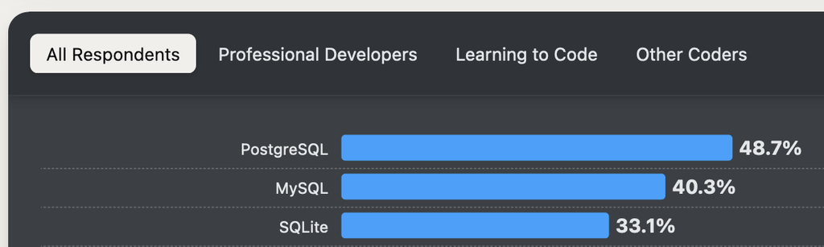

# Let’s get started! 🤓

## What is SQLite?

- SQLite is a serverless database: no server needed to run it
- It is a single file on your machine
- Pros: easy to install, lightweight, fast, great for small projects
- Cons: harder to scale, multiple writers don’t play well together (though [LiteFS](https://fly.io/docs/litefs) helps), and time-series data is better served by [TimescaleDB for Postgres](https://www.timescale.com/)
- The [`sqlean` extensions](https://github.com/nalgeon/sqlean) cover many of the gaps
- A common myth: SQLite is “not a real database” because it lives in one file
- This is false: SQLite can handle [exabyte-scale data](https://sqlite.org/hctree/doc/hctree/doc/hctree/index.html) (1M TB), far more than any classroom project will ever need
- The differences between SQL flavours are mostly small
- [Learn one and you can pick up the others quickly](https://www.postgresql.org/docs/current/sql-commands.html)

## Installing SQLite

### macOS

- SQLite already comes with macOS
- To check, open a terminal and type `sqlite3 --version`
- Type `sqlite3` to open the SQLite prompt and `.quit` to leave it
- Python’s `sqlite3` module also comes with Anaconda, so you do not need to install anything else
- For step-by-step instructions, see [Tutorial 05](https://danilofreire.github.io/datasci151-summer/05-sqlite-tutorial.html)

## Installing SQLite

### Windows

- Open the Anaconda PowerShell Prompt and run `conda install sqlite -y` (Anaconda may already include it)
- To check, type `sqlite3 --version`
- Python’s `sqlite3` module comes with Anaconda
- For step-by-step instructions, see [Tutorial 05](https://danilofreire.github.io/datasci151-summer/05-sqlite-tutorial.html)

## Installing SQLite3 Editor in VS Code

- Install the [SQLite3 Editor](https://marketplace.visualstudio.com/items?itemName=yy0931.vscode-sqlite3-editor) extension from the VS Code marketplace (or search `SQLite3 Editor` in the Extensions tab and click `Install`)
- Lets you connect to a SQLite database and run SQL inside VS Code, or edit data without writing any SQL at all
- Handles table creation, CSV / JSON export, query running, and `git diff` for database files
- We will use it today to interact with our SQLite database 😊

[figure not shown]

[Download it here](https://marketplace.visualstudio.com/items?itemName=yy0931.vscode-sqlite3-editor) or search for it in the extensions tab in VS Code

# Any issues with the installation? 🤔

# Let’s create our first SQL table! 🚀

## Creating a database with SQLite3 Editor

- It is very easy to create a [SQLite database file](https://www.sqlite.org/onefile.html) using the extension
- Simply create a file ending in `.sqlite` or `.db` and open it with the SQLite3 Editor
- Here I will create a file called `example.db` and open it with the extension
- In VS Code, click on `File` > `New File` and save the file as `example.db`
- Then just click on the file (or right-click it, select `Open With...` and choose `SQLite3 Editor`)
- You will see a new tab with the SQLite3 Editor

[figure not shown]

## Creating a table with SQLite3 Editor

- Now that you have opened the file with the extension, you will see the following screen (right)
- You will see that there is no table in the database yet (if you did Tutorial 05, you may already see a `students` table)
- Most of the time, the data come from other sources, such as APIs, JSON or CSV files
- But in small projects, it is common to create a database to store the data
- So let’s create one right now! 😉
- We will create a table with some information about [Formula 1](https://en.wikipedia.org/wiki/Formula_One) drivers
- System commands are in upper case and user-defined names are in lower case

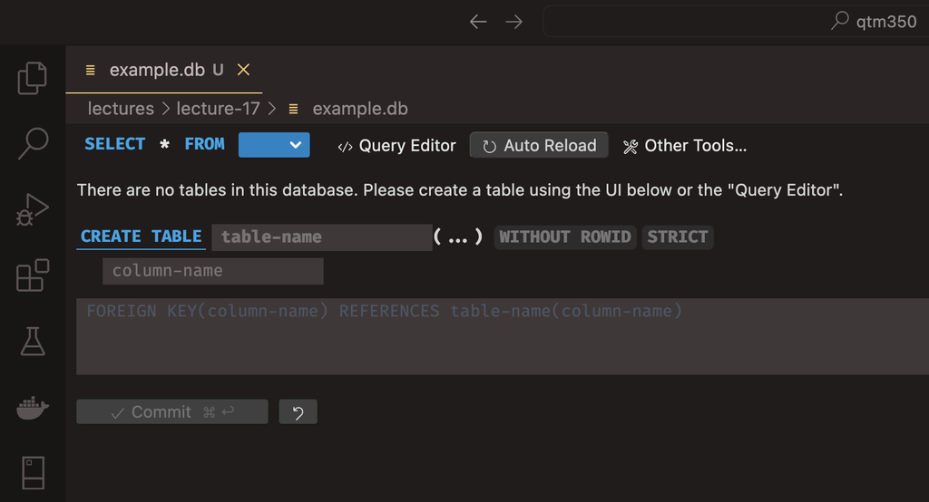

## Creating a table with SQLite3 Editor

- Now let’s create our table
- We won’t write any code yet, just add the values to the editor
- We will create four columns in the table: `driver_id`, `driver_name`, `nationality`, and `victories`:
  - `driver_id` is an `integer`, `not null`, and `primary key` (select these options in the editor)
  - `driver_name` is a `text` variable
  - `nationality` is a `text` variable too
  - `victories` is an `integer`
- Then click on `commit` to save the changes

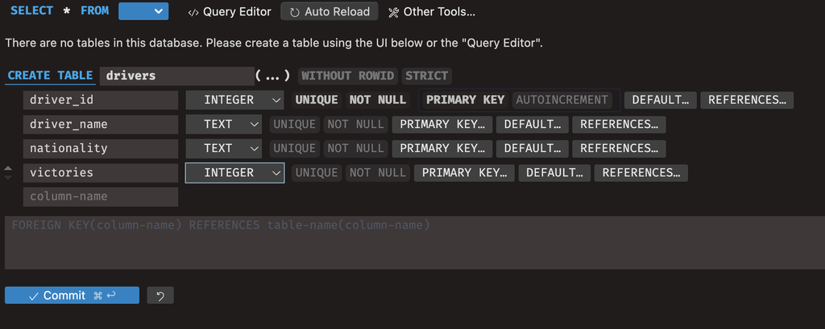

- This is equivalent to the following SQL code (as you can see in the editor):

```sql
CREATE TABLE drivers (
    driver_id INTEGER NOT NULL PRIMARY KEY,
    driver_name TEXT,
    nationality TEXT,
    victories INTEGER
);
```

## Creating a table with SQLite3 Editor

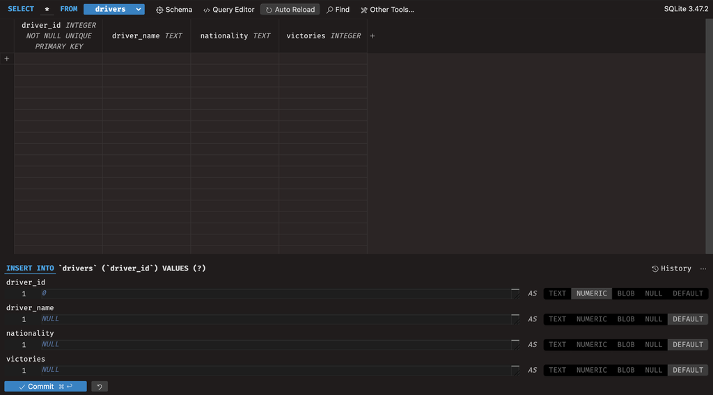

## Database structure and data types in SQLite

### Database structure

- The main object in SQL is the table (rows and columns)
- Each column has a declared data type (SQLite is flexible about enforcing it; most other databases are strict)
- Five core storage classes:
  - `TEXT`: strings (UTF-8)
  - `INTEGER`: whole numbers
  - `REAL`: decimals (floating-point, IEEE 754, 8 bytes)
  - `BLOB`: binary data, stored as-is
  - `NULL`: missing or undefined values
- Plus type affinities like `NUMERIC` and convenience names like `BOOLEAN`, `DATE`, `TIME`, `DATETIME`

### Primary and foreign keys

- The `PRIMARY KEY` uniquely identifies each row, cannot be `NULL`, and is usually an integer
- Use `AUTOINCREMENT` to generate the values for you (`driver_id INTEGER PRIMARY KEY AUTOINCREMENT`)
- The `FOREIGN KEY` links two tables: a field in one table that refers to the `PRIMARY KEY` in another
- `ROWID` is a hidden auto-generated column, but avoid it: its values can be reused for new rows after deletions (so a stale reference may point at a different row) and the column is not portable across SQL databases

## Example of tables with primary and foreign keys

- Imagine that we have three tables, `customers`, `products`, and `orders`
- The `customers` table will have a primary key `customer_id`
- The `products` table will have a primary key `product_id`
- And the `orders` table will have a primary key `order_id`
- The `orders` table will also have two foreign keys: `customer_id` and `product_id`
- We will see more about this in the next classes

customers

| customer_id (PK) | first_name | last_name | email |
| --- | --- | --- | --- |
| 1 | John | Doe | john.doe@email.com |
| 2 | Jane | Smith | jane.smith@email.com |
| 3 | Bob | Johnson | bob.j@email.com |

products

| product_id (PK) | product_name | price |
| --- | --- | --- |
| 101 | Laptop | 999.99 |
| 102 | Smartphone | 599.99 |
| 103 | Wireless Mouse | 29.99 |

orders

| order_id (PK) | customer_id (FK) | product_id (FK) | quantity | total_price |
| --- | --- | --- | --- | --- |
| 1 | 1 | 101 | 1 | 999.99 |
| 2 | 2 | 102 | 2 | 1199.98 |
| 3 | 3 | 103 | 3 | 89.97 |

## Add rows to table using the editor

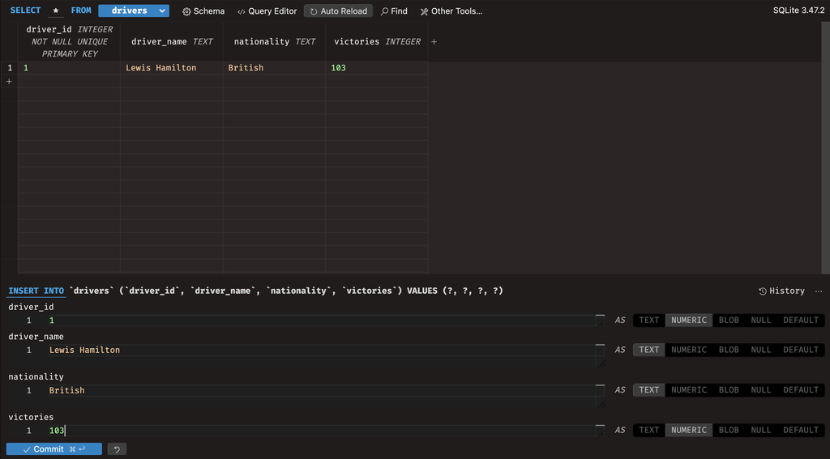

## Adding rows to the table using SQL commands

- Use the `INSERT INTO` command to add rows to a table
- It appends new rows (with `VALUES`) to the bottom of the table
- In SQL, different commands need to be separated by a semicolon (`;`)
- Write system commands in capital letters to distinguish them from column names, variables, and values
- Let’s add some information about the drivers
- Click on `Query Editor` and paste the following code:

```sql
INSERT INTO drivers VALUES (2, 'Michael Schumacher', 'German', 91);
INSERT INTO drivers VALUES (3, 'Sebastian Vettel', 'German', 53);
INSERT INTO drivers VALUES (4, 'Fernando Alonso', 'Spanish', 32);
```

Or more efficiently (run one block or the other, not both, as the same `driver_id` cannot be inserted twice):

```sql
INSERT INTO drivers (driver_id, driver_name, nationality, victories) VALUES
(2, 'Michael Schumacher', 'German', 91),
(3, 'Sebastian Vettel', 'German', 53),
(4, 'Fernando Alonso', 'Spanish', 32);
```

- Now click on `▶️️ Execute` ️to run the code

## Adding rows to the table

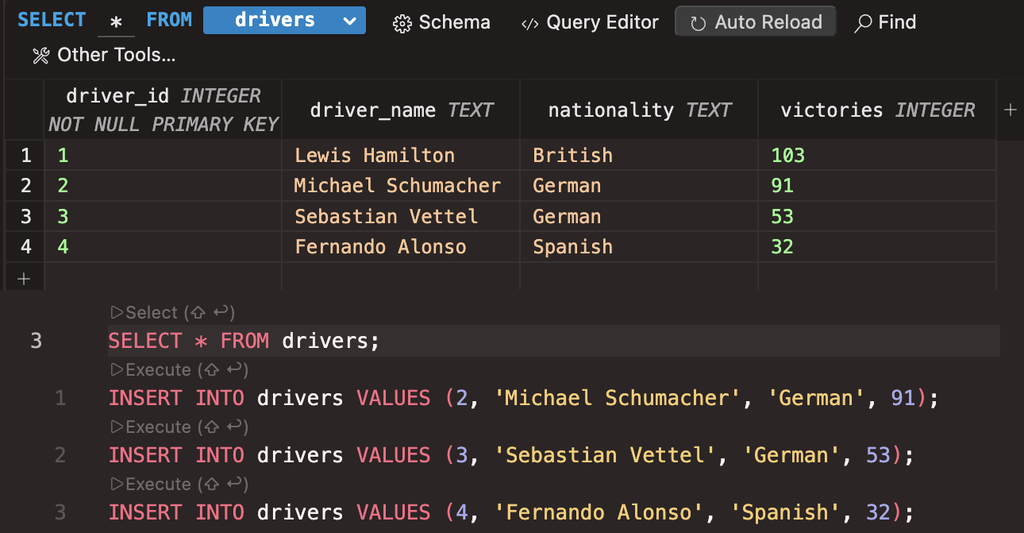

## Querying the table

- The editor already shows all the rows in the table, but we can also query the table using the `SELECT` command

```sql
SELECT * FROM drivers;
```

- This command selects all columns (`*`) from the `drivers` table
- `SELECT` is probably the most used command in SQL and is used to extract data from a database
- If you are running SQL in the command line, you need to type `SELECT` to see the results

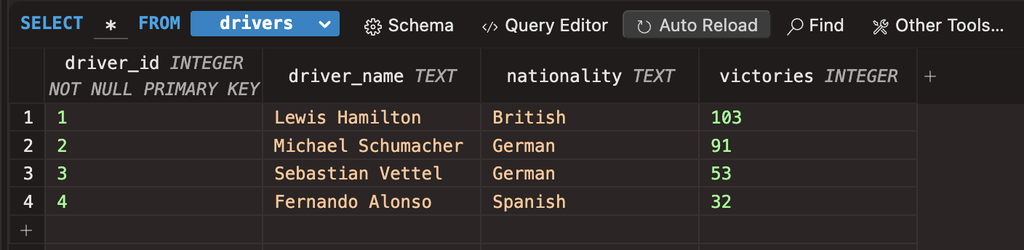

## Exercise 01

- Click on `Query Editor` and create a table called `students` with the following columns:
  - `student_id` (integer not null primary key)
  - `student_name` (text)
  - `major` (text)
  - `gpa` (numeric)
- Add the following rows to the table:
  - `student_id`: 1, `student_name`: ‘John Doe’, `major`: ‘Computer Science’, `gpa`: 3.5
  - `student_id`: 2, `student_name`: ‘Jane Doe’, `major`: ‘Mathematics’, `gpa`: 3.8
- Query the table to see the results
- If the table already exists on your database, drop it first with `DROP TABLE IF EXISTS students;`
- Appendix 01

# Table schemas 📄

## What is a table schema?

- The [table schema](https://en.wikipedia.org/wiki/Database_schema) is the structure of a table: its columns, data types, constraints, and relationships
- Defined when the table is created, but can be modified later (though you usually won’t need to)
- View it with the `PRAGMA table_info()` command

`PRAGMA table_info()` returns one row per column with:

- `cid`: column ID
- `name`: column name
- `type`: data type
- `notnull`: 1 if `NULL` is forbidden, 0 otherwise
- `dflt_value`: default value
- `pk`: 1 if part of the primary key, 0 otherwise

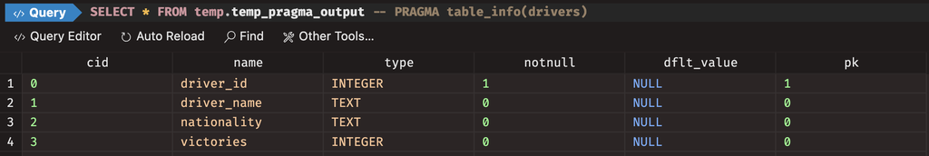

## Creating and modifying table schemas

- To create a table, use the `CREATE TABLE` command, as we saw before
- Use the `IF NOT EXISTS` clause to avoid errors when the table already exists
  - Example: `CREATE TABLE IF NOT EXISTS table_name (column1_name data_type, ...);`
- Use `ALTER TABLE` to modify an existing table:
  - Add a column: `ALTER TABLE table_name ADD column_name data_type;`
  - Drop a column: `ALTER TABLE table_name DROP COLUMN column_name;`
  - Rename a column: `ALTER TABLE table_name RENAME COLUMN old_name TO new_name;`
- To delete a table, use the `DROP TABLE` command
  - Example: `DROP TABLE table_name;`
  - Be careful: this deletes all the data in the table!
- To delete rows, use the `DELETE FROM` command
  - Example: `DELETE FROM table_name WHERE condition;`
  - Deletes all rows that satisfy the condition
  - Without a condition, it deletes every row in the table

## Some examples with the `students` table

- Add a column: `ALTER TABLE students ADD COLUMN age INTEGER;`

[figure not shown]

- Drop a column: `ALTER TABLE students DROP COLUMN major;`

[figure not shown]

- Rename a column: `ALTER TABLE students RENAME COLUMN gpa TO grade;`

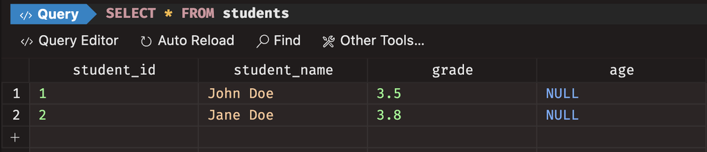

- Delete a row with `student_id = 2`: `DELETE FROM students WHERE student_id = 2;`

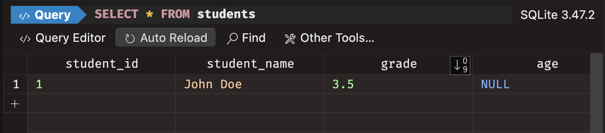

# Table operations 📊

## Extracting columns from table

### SELECT extracts certain columns

- The `SELECT` command extracts certain columns from a table

```sql
SELECT driver_id, nationality FROM drivers;
```

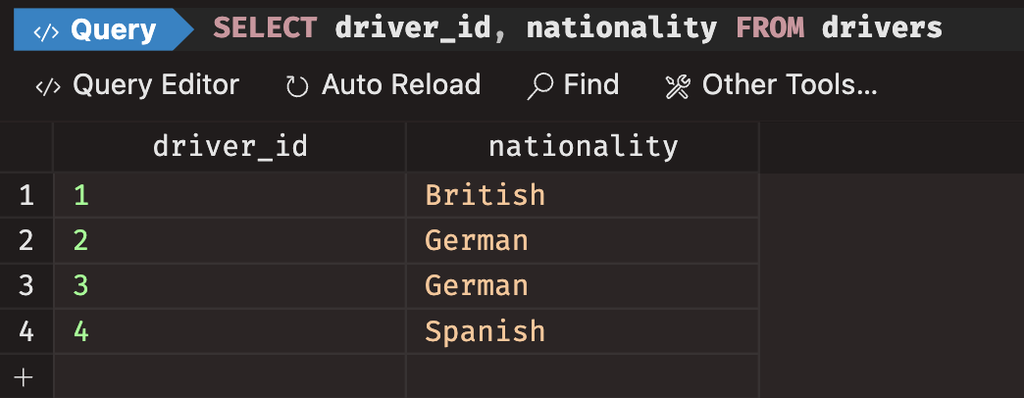

### Subsetting rows

- The `WHERE` command evaluates logical conditions to subset rows

```sql
SELECT * FROM drivers
WHERE nationality = 'German';
```

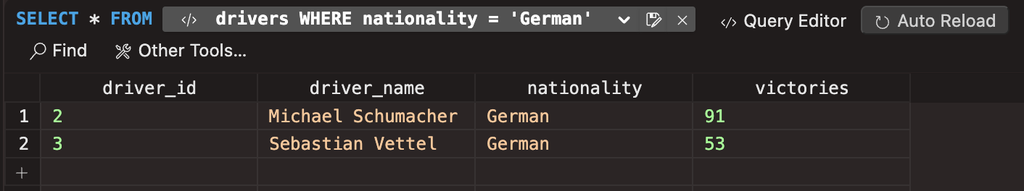

## AND and OR conditions

### OR conditions

- Evaluate OR conditions

```sql
SELECT * FROM drivers
WHERE (nationality = 'Spanish') OR (nationality = 'German');
```

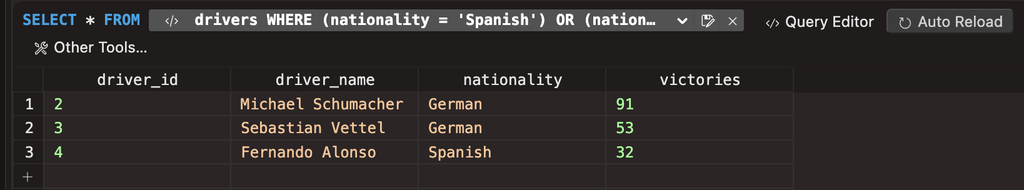

### AND conditions

- Evaluate AND conditions

```sql
SELECT * FROM drivers
WHERE (nationality = 'German') AND (driver_id = 3);
```

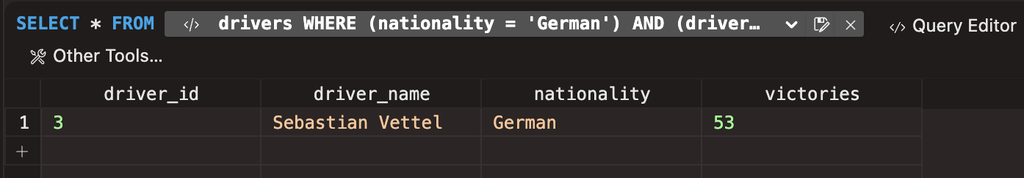

## Data description

### Aggregate

- To compute aggregate statistics, use a statistic function such as `SUM()` or `AVG()`
- Use `AS` to give the aggregate statistic a name (an *alias*)

```sql
SELECT SUM(victories) AS sum_victories,
       COUNT(*) AS num_rows,
       AVG(victories) AS mean_victories,
       MIN(victories) AS min_victories,
       MAX(victories) AS max_victories
FROM drivers;
```

[figure not shown]

### Sort

- Use `ORDER BY` to sort the data
- Use `ASC` for ascending order and `DESC` for descending

```sql
SELECT driver_name, victories FROM drivers
ORDER BY victories ASC;
```

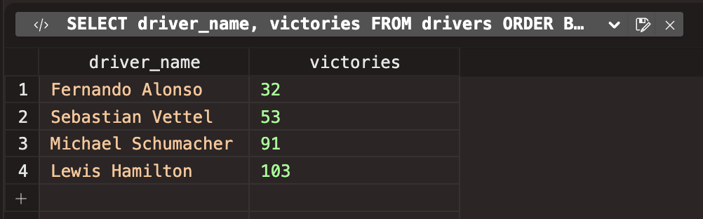

## Exercise 02

- List drivers who are either ‘German’ or ‘British’ and have victories greater than 50
- List all drivers with victories greater than the average victories
  - Hint: you will have to run another `SELECT` command to get the average victories (a subquery)
  - Aggregate functions are not allowed in the `WHERE` clause. [See the reason why here](https://stackoverflow.com/questions/42470849/why-are-aggregate-functions-not-allowed-in-where-clause). [More about subqueries here.](https://mode.com/sql-tutorial/sql-sub-queries)
  - We will see another way to do this soon (with `HAVING`)
- Appendix 02

## Groupby + Aggregate

### Groupby

- Use `GROUP BY` to group data by a column

```sql
SELECT nationality,
       SUM(victories) AS sum_victories,
       AVG(victories) AS mean_victories,
       MIN(victories) AS min_victories,
       MAX(victories) AS max_victories
FROM drivers
GROUP BY nationality;
```

[figure not shown]

### Round

- Use `ROUND()` to round the values
- The first argument is the value to round, the second is the number of decimal places
- The results match the previous slide, except that `mean_victories` is now rounded to one decimal place

```sql
SELECT nationality,
       SUM(victories) AS sum_victories,
       ROUND(AVG(victories), 1) AS mean_victories,
       MIN(victories) AS min_victories,
       MAX(victories) AS max_victories
FROM drivers
GROUP BY nationality;
```

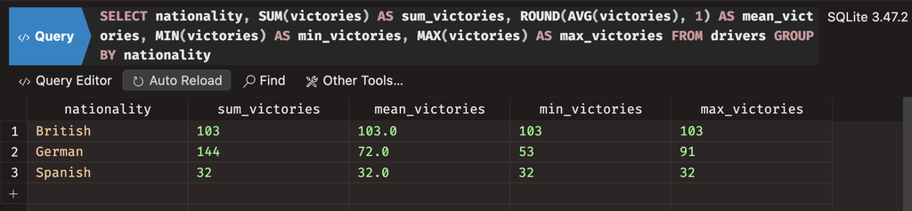

## Filtering after aggregating with HAVING

- `HAVING` filters rows after aggregating
- `WHERE` filters rows before aggregating
- Position in the query: `HAVING` goes after `GROUP BY` and before `ORDER BY`

```sql
SELECT nationality,
       SUM(victories) AS sum_victories,
       ROUND(AVG(victories), 1) AS mean_victories,
       MIN(victories) AS min_victories,
       MAX(victories) AS max_victories
FROM drivers
GROUP BY nationality
HAVING SUM(victories) > 50;
```

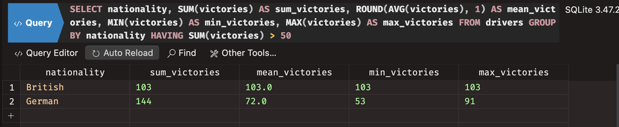

## Python vs. SQL

- Common SQL commands and their pandas equivalents:

| SQL command | Pandas equivalent |
| --- | --- |
| `SELECT` | `df[['column1', 'column2']]` |
| `INSERT INTO` | `pd.concat([df, pd.DataFrame([new_row])], ignore_index=True)` |
| `WHERE` | `df[df['column'] == value]` |
| `GROUP BY` | `df.groupby('column')` |
| `HAVING` | `df.groupby('column').filter(lambda x: condition)` |
| Aggregations | `df.groupby('column').agg({'col1': 'sum', 'col2': 'mean'})` |

```sql
-- SQL
SELECT nationality,
       SUM(victories) AS sum_victories
FROM drivers
GROUP BY nationality
HAVING SUM(victories) > 10;
```

```python
# Python
import pandas as pd

# Group by 'nationality' and calculate 'sum_victories' using agg()
result = (
    drivers.groupby('nationality')
    .agg(sum_victories=('victories', 'sum'))
    .reset_index()
)

# Apply 'HAVING' condition
result = result[result['sum_victories'] > 10]
```

## Importing and exporting data

- The SQLite3 Editor exports data to CSV, JSON, XLSX and SQL, and imports from CSV, JSON and SQL. Click `Other Tools` → `Export / Import`
- For XLSX, you can export one table or all of them at once
- Importing is just as easy: pick the file and choose which table to load into
- From the command line:
  - Export to CSV: `sqlite3 -cmd ".headers on" -cmd ".mode csv" -cmd ".output example.csv" example.db "SELECT * FROM drivers;"` ([guide](https://www.sqlitetutorial.net/sqlite-export-csv/))
  - Import from CSV into a new table, `drivers_copy`: `sqlite3 -cmd ".mode csv" example.db ".import example.csv drivers_copy"` ([guide](https://www.sqlitetutorial.net/sqlite-import-csv/))
  - Importing into `drivers` again would fail, as its `driver_id` values already exist

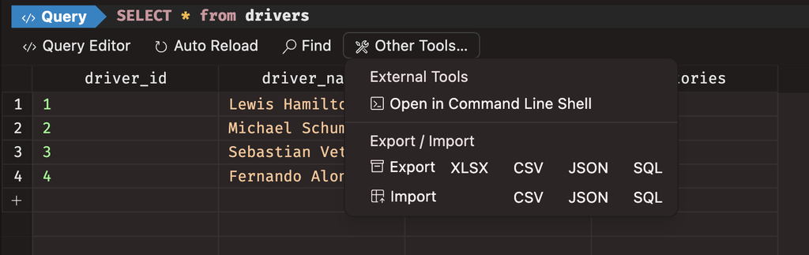

## Do you want to learn more? 🤓

- Here is a list of resources to help you learn more about SQL:
  - [Overview of the SQLite3 Extension](https://marketplace.visualstudio.com/items?itemName=yy0931.vscode-sqlite3-editor): Worth reading to understand all the features of the extension
  - [SQLean](https://github.com/nalgeon/sqlean): SQLite extensions. macOS users should install the sqlean.py Python package, as sqlite3 is compiled without extension support
  - [SQLBolt](https://sqlbolt.com/): Interactive SQL tutorials
  - [W3Schools](https://www.w3schools.com/sql/): SQL tutorials
  - [Kaggle](https://www.kaggle.com/learn/intro-to-sql): SQL course
  - [Mode Analytics](https://mode.com/sql-tutorial/): SQL tutorial
  - [SQLZoo](https://sqlzoo.net/): Interactive SQL tutorials
  - [SQL for Data Science](https://www.datacamp.com/courses/sql-for-data-science): DataCamp course
  - [SQL for Data Science](https://www.coursera.org/learn/sql-for-data-science): Coursera course
- Or just come to our next class! 😊

# And that’s it for today! 🚀

# See you next time! 😊

## Appendix 01

- Here is the code to create the `students` table and add the rows
- You can paste this code into the SQL editor and execute the commands

```sql
DROP TABLE IF EXISTS students;

CREATE TABLE students(
    student_id INTEGER NOT NULL PRIMARY KEY,
    student_name TEXT,
    major TEXT,
    gpa NUMERIC
);

INSERT INTO students VALUES
(1, 'John Doe', 'Computer Science', 3.5),
(2, 'Jane Doe', 'Mathematics', 3.8);

SELECT * FROM students;
```

- Back to exercise

## Appendix 02

- Here is the code to list drivers who are either ‘German’ or ‘British’ and have victories greater than 50

```sql
SELECT driver_name, nationality, victories
FROM drivers
WHERE (nationality = 'German' OR nationality = 'British') AND victories > 50;

SELECT driver_name, victories
FROM drivers
WHERE victories > (SELECT AVG(victories) FROM drivers);
```

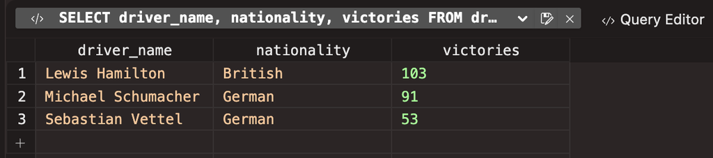

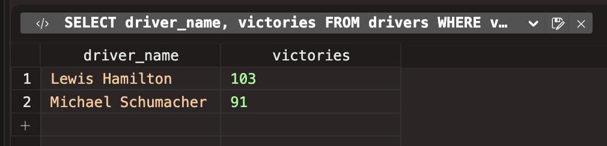

- Back to exercise